# Final Project

# Section 4

## Model Evaluation

**Cross Validation Scheme.**  
I adjusted the initial value to 80 to cover roughly half of the dataset, and then incremented it by 6 for each subsequent step.

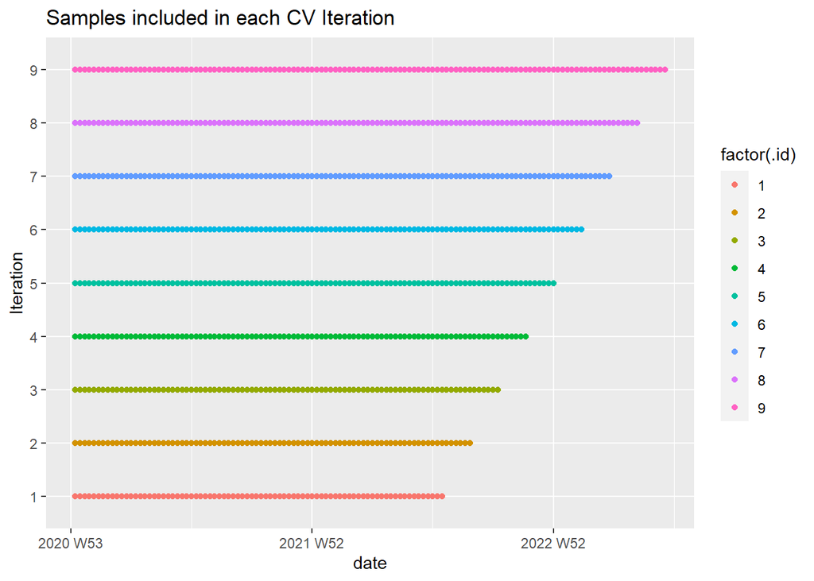

```r
rd_cv = rd_train %>%
  stretch_tsibble(.init = 80, .step = 6)

rd_cv %>%
    ggplot()+
    geom_point(aes(date,factor(.id),color=factor(.id)))+
    ylab('Iteration')+
    ggtitle('Samples included in each CV Iteration')
```

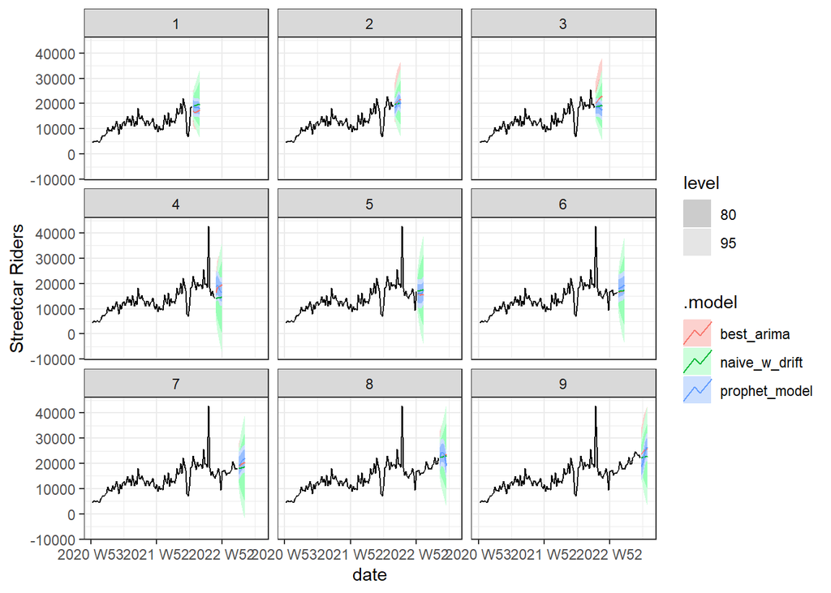

```r
rd_cv_forecast = rd_cv %>%
  model(
    naive_w_drift = NAIVE(ridership~drift()),
    best_arima = ARIMA(log(ridership)~pdq(1,1,3)+PDQ(0,0,0)),
    prophet_model = prophet(ridership)) %>%
  forecast(h = 6)

rd_cv_forecast %>%
  autoplot(rd_cv)+
  facet_wrap(~.id,nrow=4)+
  theme_bw()+
  ylab('Streetcar Riders')
```

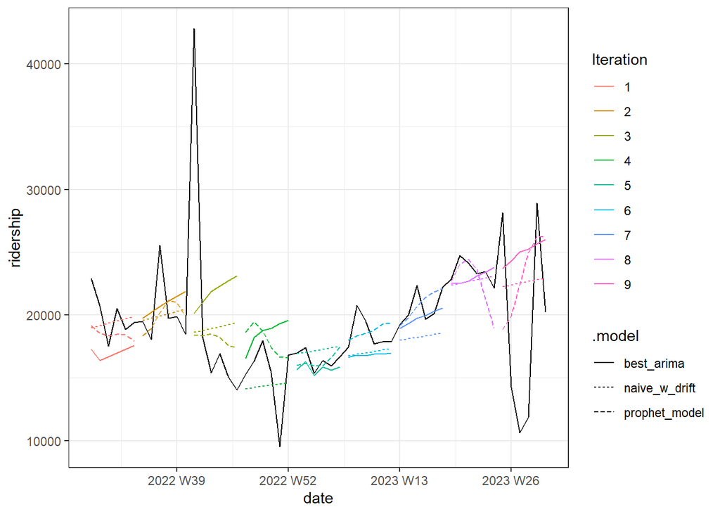

```r
rd_cv_forecast %>%
    as_tsibble() %>%
    dplyr::select(-ridership) %>%
    left_join(
        rd_tsbl
    ) %>%
    ggplot()+
    geom_line(aes(date,ridership))+
    geom_line(aes(date,.mean,color=factor(.id),linetype=.model))+
    scale_color_discrete(name='Iteration')+
    theme_bw()
```

Based on the graph above, it seems that for the fifth iteration post January 2023, Prophet model appears to offer a better fit. I think comparatively Ptophet model offers a better fit.

## Model Performance at each Horizon

**Distribution of Absolute Error at each Horizon**

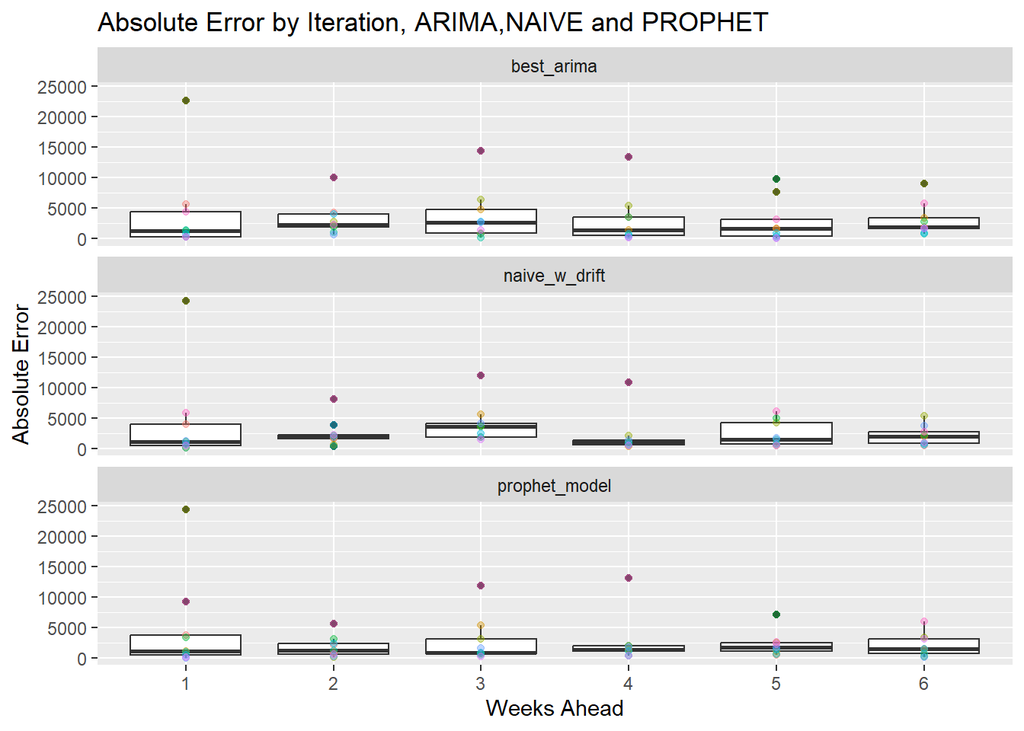

```r
rd_cv_forecast %>%
  as_tibble() %>%
  dplyr::select(-ridership) %>%
  left_join(rd_tsbl) %>%
  group_by(.id,.model) %>%
  mutate(
    weeks_ahead = seq(1:6)
  ) %>%
  ungroup() %>%
  mutate(error = abs(ridership - .mean)) %>%
  ggplot()+
  geom_boxplot(aes(factor(weeks_ahead),error))+
  geom_point(aes(factor(weeks_ahead),error,color=factor(.id)),alpha=0.4)+
  facet_wrap(~.model,ncol=1)+
  guides(color='none')+
  ylab('Absolute Error')+
  xlab('Weeks Ahead')+
  ggtitle('Absolute Error by Iteration, ARIMA,NAIVE and PROPHET')
```

**RMSE at each Horizon**

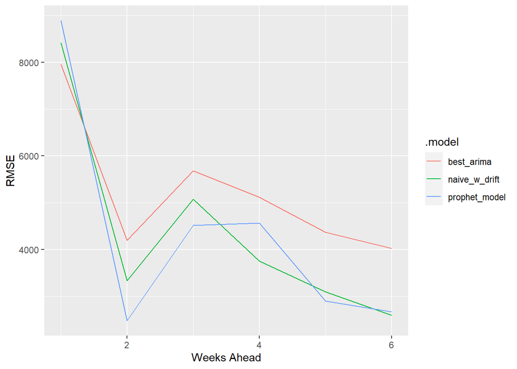

```r
rd_cv_forecast %>%
  as_tibble() %>%
  dplyr::select(-ridership) %>%
  left_join(rd_tsbl) %>%
  group_by(.id,.model) %>%
  mutate(
    weeks_ahead = seq(1:6)
  ) %>%
  ungroup() %>%
  filter(!is.na(ridership)) %>%
  group_by(weeks_ahead,.model) %>%
  summarize(
    rmse = sqrt(mean((ridership - .mean)^2,na.rm=T)),
  ) %>%
  ungroup() %>%
  ggplot()+
  geom_line(aes(weeks_ahead,rmse,color=.model))+
  xlab("Weeks Ahead")+
  ylab("RMSE")
```

**Full Error Metrics by Iteration**

```r
rd_cv_forecast %>%
  group_by(.id) %>%
  accuracy(rd_tsbl) %>%
  ungroup() %>%
  data.table()
```

```
           .model .id .type         ME       RMSE       MAE         MPE
 1:    best_arima   1  Test  2967.4242  3407.9103 2967.4242  14.2677778
 2:    best_arima   2  Test  -657.1825  2708.2340 2265.1767  -4.6138104
 3:    best_arima   3  Test -1459.0293 11066.3561 9020.2562 -25.3359688
 4:    best_arima   4  Test -3367.4439  4524.5939 3367.4439 -27.9724516
 5:    best_arima   5  Test   710.6321   822.9120  710.6321   4.2299208
 6:    best_arima   6  Test  1711.1118  2104.4660 1711.1118   8.8634387
 7:    best_arima   7  Test   789.5543  1306.6524  951.5634   3.5817693
 8:    best_arima   8  Test   432.3951  1287.1908  982.6729   1.6676560
 9:    best_arima   9  Test -6002.0607  9586.8303 8549.0620 -53.4697163
10: naive_w_drift   1  Test   555.0506  1953.9030 1596.3165   2.0306244
11: naive_w_drift   2  Test   172.3333  2533.4865 1693.0000  -0.4482719
12: naive_w_drift   3  Test  1394.6154 10395.4258 6665.3004  -8.0587462
13: naive_w_drift   4  Test   833.2612  2880.7251 2506.2955   1.1638227
14: naive_w_drift   5  Test  -756.1181  1070.4553  897.1796  -4.7793759
```

[output cut: 43 more lines]

**Average Accuracy Comparison**

```r
rd_cv_forecast %>%
  accuracy(rd_tsbl) %>%
  data.table()
```

```
          .model .type        ME     RMSE      MAE       MPE     MAPE      MASE
1:    best_arima  Test -541.6221 5398.169 3391.705 -8.753487 20.02323 0.5768773
2: naive_w_drift  Test  341.7470 4797.875 2863.272 -3.048425 15.80648 0.4869990
3: prophet_model  Test -227.4178 4866.163 2723.302 -6.270873 15.28177 0.4631923
       RMSSE       ACF1
1: 0.7743307 0.23506729
2: 0.6882226 0.07593981
3: 0.6980181 0.13608627
```

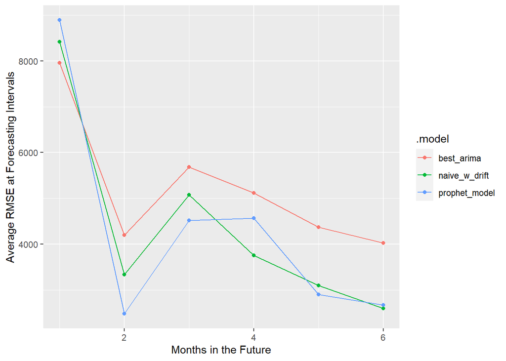

```r
rd_cv_forecast %>%
  group_by(.id,.model) %>%
  mutate(h = row_number()) %>%
  ungroup() %>%
  as_fable(response = "ridership", distribution = ridership) %>%
  accuracy(rd_tsbl, by = c("h", ".model")) %>%
  ggplot(aes(x = h, y = RMSE,color=.model)) +
  geom_point()+
  geom_line()+
  ylab('Average RMSE at Forecasting Intervals')+
  xlab('Months in the Future')
```

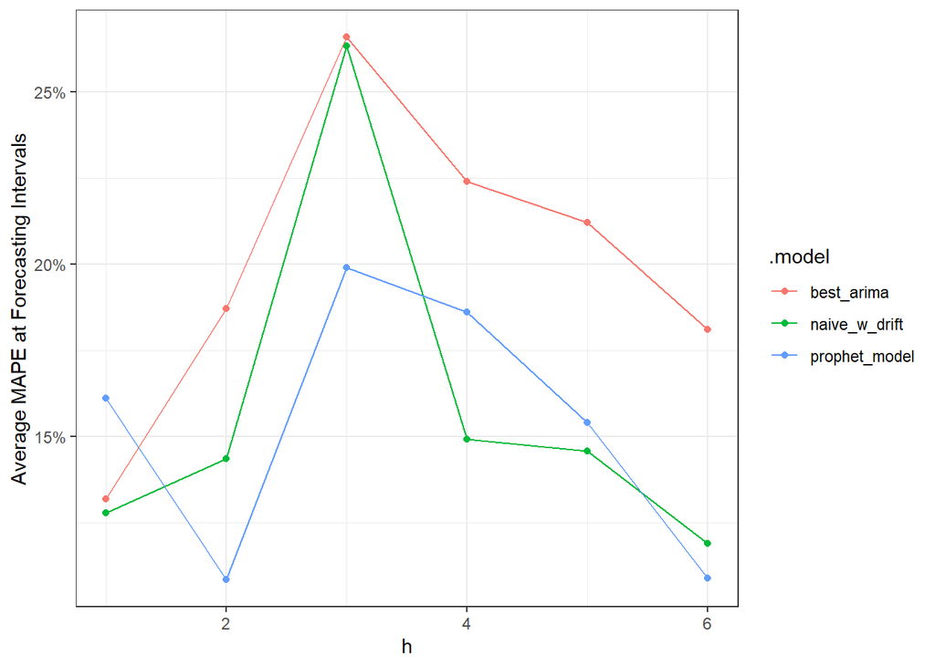

```r
rd_cv_forecast %>%
  group_by(.id,.model) %>%
  mutate(h = row_number()) %>%
  ungroup() %>%
  as_fable(response = "ridership", distribution = ridership) %>%
  accuracy(rd_tsbl, by = c("h", ".model")) %>%
  mutate(MAPE = MAPE/100) %>% # Rescale
  ggplot(aes(x = h, y = MAPE,color=.model)) +
  geom_point()+
  geom_line()+
  theme_bw()+
  scale_y_continuous(
    name = 'Average MAPE at Forecasting Intervals',labels=scales::percent)
```

After comparing the RMSE and MAPE plots shown above, it can be inferred that the Prophet forecast model performs better than best ARIMA for our time series forecasting. This aligns with our initial intuition.

## Final Test Set Forecast

```r
rd_train_mod <- rd_train %>%
  model(
    prophet(ridership)
  )
```

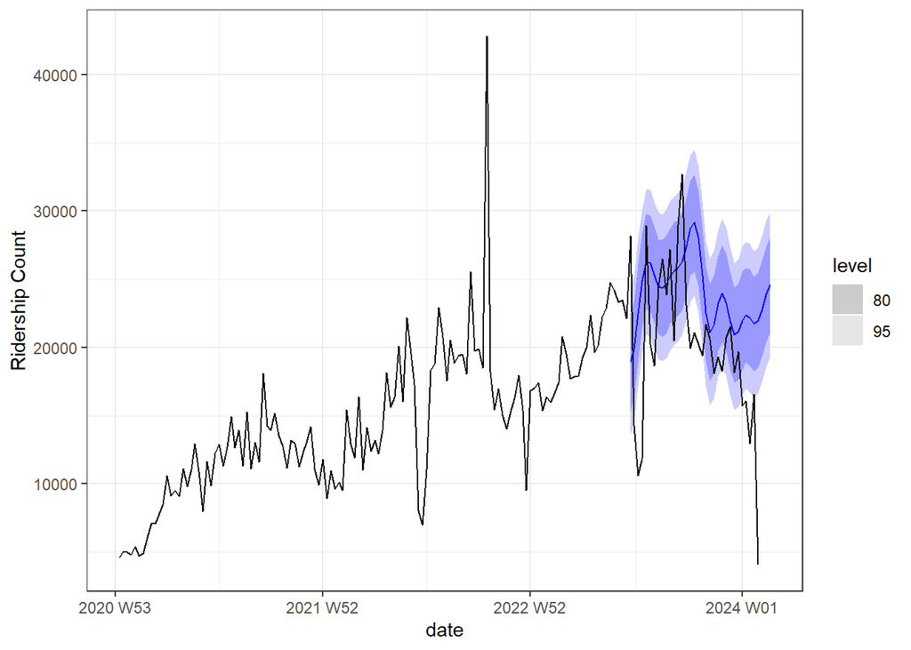

```r
rd_train_mod %>%
    forecast(h=36) %>%
    autoplot(rd_train %>%
    bind_rows(rd_test))+
    ylab('Ridership Count')+
    theme_bw()
```

```r
rd_train_mod %>%
    forecast(h=36) %>%
    accuracy(rd_test)
```

```
# A tibble: 1 × 10
  .model             .type     ME  RMSE   MAE   MPE  MAPE  MASE RMSSE  ACF1
  <chr>              <chr>  <dbl> <dbl> <dbl> <dbl> <dbl> <dbl> <dbl> <dbl>
1 prophet(ridership) Test  -3803. 6624. 5343. -35.7  41.0   NaN   NaN 0.201
```

Upon identifying the best-performing model, we proceeded to refit that model using the entire training set and generated forecasts for the test set. Subsequently, we visualized the actual versus predicted values for the test set and recalculated the performance metrics for this selected model.

These results indicate high variance in the data, suggesting overfitting. The model appears to be capturing noise from the training data rather than underlying patterns, leading to poor performance on unseen data. Therefore, there is considerable room for improvement.

## Forecast for the Prophet Model

```r
rd_full_model <- rd_tsbl %>%
  model(
    prophet = fable.prophet::prophet(ridership~growth()+season(period='year', type = 'additive'))
  )
```

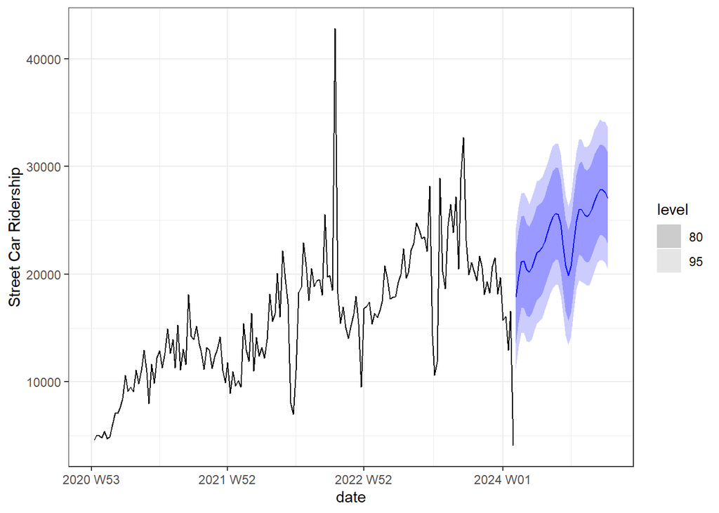

```r
rd_full_model %>%
    forecast(h=36) %>%
    autoplot(rd_tsbl) %>%+
    ylab('Street Car Ridership')+
    theme_bw()
```

he forecasted values appear to align well with the observed trend, indicating a consistent pattern where at the beginning of each year, there’s a decline followed by a subsequent increase. This pattern suggests a recurring yearly cycle within the data, with the forecast capturing this trend effectively.

In summary, the forecasted values reflect the expected behavior of the time series, showing a cyclic pattern characterized by a dip at the start of each year followed by a rise, which aligns with the observed trend in the data.